# Practical Machine Learning Course Project

Using Wireless Wearable Technology to Predict Weightlifting Technique

Joel Hickman

6/2/2020

### Overview and Executive Summary

In this project, I will use the *HAR data* http://groupware.les.inf.puc-rio.br/har using wearable technology (Jawbone Up, Nike Fuelband, and Fitbit) to try and predict how well an individual preferms weightlifting exercises. The “classe” variable within the data determines the manner in which the participant performed the exercise and will be used as the prediction variable.

### Exploratory Data Analysis

```r
rm(list = ls())
library(knitr)
library(caret)
library(rpart)
library(rpart.plot)
library(rattle)
library(randomForest)
library(gbm)
library(dplyr)
```

# Read in Training and Test Set Data

```r
set.seed(12512)

trainData <- read.csv("pml_training.csv", na.strings = c("", "NA"), header = TRUE)
testData  <- read.csv("pml_testing.csv", na.strings = c("", "NA"), header = TRUE)
```

# Clean Data

```r
dim(trainData)
head(trainData)
```

[output not shown]

After observation, the data set contains a number of variables with a large number of missing (NA) data. We will remove variables with over 90% NA’s from the both the training and test data sets as they add little to no value for model prediction. Some of the variables at the beginning of the data set can be removed since they are either ID variables or date/time stamp related.

```r
trainData <- trainData[,-c(1:7)]
testData <- testData[,-c(1:7)]

varsNA <- sapply(trainData, function(x) mean(is.na(x))) > 0.9
trainData <- trainData[,varsNA==FALSE]
testData  <- testData[,varsNA==FALSE]

dim(trainData)
```

```
## [1] 19622    53
```

# Partition the Data

```r
library(iterators)
library(parallel)
library(foreach)
library(doParallel)

cluster <- makeCluster(detectCores()-1)
registerDoParallel(cluster)
getDoParWorkers()
```

```
## [1] 3
```

```r
set.seed(54242)
trainData$classe <- as.factor(trainData$classe)
testData$classe  <= as.factor(testData$classe)
```

```
## logical(0)
```

```r
inTrain <- createDataPartition(y = trainData$classe, p = 0.6, list = FALSE)
trainData <- trainData[inTrain,]
valData   <- trainData[-inTrain,]
```

# Modeling

The following methods will be evaluated:

```
1. Decision Trees
2. Random Forests
3. Gradient Boosted Machines
```

# Decision Trees

Start by training the model with decision trees. We will set each of the models to run with 5-fold cross validation.

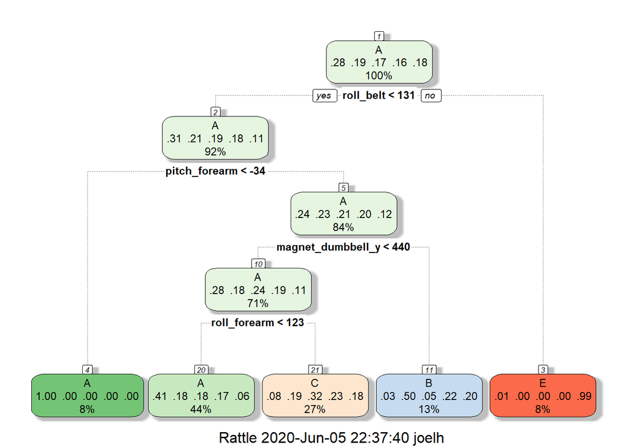

```r
set.seed(7527)
library(e1071)
trControl <- trainControl(method="cv", number = 5, allowParallel = TRUE)
model.dt <- train(classe ~ ., data = trainData, method = "rpart", trControl = trControl)
fancyRpartPlot(model.dt$finalModel)
```

Next, predict on the validation and evaluate model performance.

```r
predict.dt <- predict(model.dt, newdata = valData)
confusionMatrix(predict.dt, valData$classe)
```

```
## Confusion Matrix and Statistics
##
##           Reference
## Prediction    A    B    C    D    E
##          A 1217  364  369  356  140
##          B   16  301   35  142  140
##          C  100  246  424  273  238
##          D    0    0    0    0    0
##          E    2    0    0    0  360
##
## Overall Statistics
##
##                Accuracy : 0.4874
##                  95% CI : (0.4731, 0.5018)
##     No Information Rate : 0.2827
##     P-Value [Acc > NIR] : < 2.2e-16
##
##                   Kappa : 0.3307
##
##  Mcnemar's Test P-Value : NA
##
## Statistics by Class:
##
##                      Class: A Class: B Class: C Class: D Class: E
## Sensitivity            0.9116  0.33041  0.51208   0.0000  0.41002
## Specificity            0.6372  0.91264  0.77997   1.0000  0.99948
## Pos Pred Value         0.4975  0.47476  0.33099      NaN  0.99448
## Neg Pred Value         0.9482  0.85082  0.88263   0.8368  0.88122
## Prevalence             0.2827  0.19289  0.17531   0.1632  0.18590
## Detection Rate         0.2577  0.06373  0.08977   0.0000  0.07622
## Detection Prevalence   0.5179  0.13424  0.27123   0.0000  0.07665
## Balanced Accuracy      0.7744  0.62153  0.64603   0.5000  0.70475
```

# Random Forests

Start by training the model on the training data.

```r
set.seed(7527)
model.rf <- train(classe ~ ., data = trainData, method = "rf", ntree = 250, trControl = trControl, verbose = TRUE)
model.rf
```

```
## Random Forest
##
## 11776 samples
##    52 predictor
##     5 classes: 'A', 'B', 'C', 'D', 'E'
##
## No pre-processing
## Resampling: Cross-Validated (5 fold)
## Summary of sample sizes: 9420, 9422, 9421, 9421, 9420
## Resampling results across tuning parameters:
##
##   mtry  Accuracy   Kappa
##    2    0.9891311  0.9862493
##   27    0.9898954  0.9872172
##   52    0.9853098  0.9814166
##
## Accuracy was used to select the optimal model using the largest value.
## The final value used for the model was mtry = 27.
```

[figure not shown]

```r
plot(model.rf, main = "Random Forest: Error Rate vs. Number of Trees")
```

Next, apply the model to the validation data and evaluate model performance.

```r
predict.rf <- predict(model.rf, newdata = valData)
confusionMatrix(predict.rf, valData$classe)
```

```
## Confusion Matrix and Statistics
##
##           Reference
## Prediction    A    B    C    D    E
##          A 1335    0    0    0    0
##          B    0  911    0    0    0
##          C    0    0  828    0    0
##          D    0    0    0  771    0
##          E    0    0    0    0  878
##
## Overall Statistics
##
##                Accuracy : 1
##                  95% CI : (0.9992, 1)
##     No Information Rate : 0.2827
##     P-Value [Acc > NIR] : < 2.2e-16
##
##                   Kappa : 1
##
##  Mcnemar's Test P-Value : NA
##
## Statistics by Class:
##
##                      Class: A Class: B Class: C Class: D Class: E
## Sensitivity            1.0000   1.0000   1.0000   1.0000   1.0000
## Specificity            1.0000   1.0000   1.0000   1.0000   1.0000
## Pos Pred Value         1.0000   1.0000   1.0000   1.0000   1.0000
## Neg Pred Value         1.0000   1.0000   1.0000   1.0000   1.0000
## Prevalence             0.2827   0.1929   0.1753   0.1632   0.1859
## Detection Rate         0.2827   0.1929   0.1753   0.1632   0.1859
## Detection Prevalence   0.2827   0.1929   0.1753   0.1632   0.1859
## Balanced Accuracy      1.0000   1.0000   1.0000   1.0000   1.0000
```

# Gradient Boosted Machines

Next, we run a GBM model on the training data.

```r
set.seed(7527)
model.gbm <- train(classe ~ ., data = trainData, method = "gbm", trControl = trControl, verbose = TRUE)
model.gbm$finalModel
```

```
## A gradient boosted model with multinomial loss function.
## 150 iterations were performed.
## There were 52 predictors of which 52 had non-zero influence.
```

And then we run the GBM model on the validation data set.

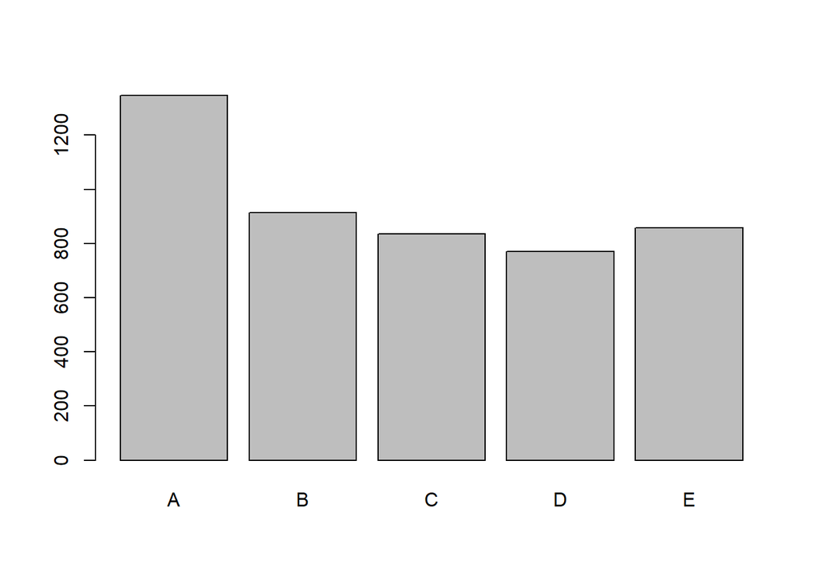

```r
predict.gbm <- predict(model.gbm, newdata = valData)
plot(predict.gbm)
```

```r
confusionMatrix(predict.gbm, valData$classe)
```

```
## Confusion Matrix and Statistics
##
##           Reference
## Prediction    A    B    C    D    E
##          A 1319   26    0    0    2
##          B   10  874   19    7    3
##          C    4   11  802   13    6
##          D    2    0    7  750   11
##          E    0    0    0    1  856
##
## Overall Statistics
##
##                Accuracy : 0.9742
##                  95% CI : (0.9692, 0.9785)
##     No Information Rate : 0.2827
##     P-Value [Acc > NIR] : < 2.2e-16
##
##                   Kappa : 0.9673
##
##  Mcnemar's Test P-Value : 4.256e-06
##
## Statistics by Class:
##
##                      Class: A Class: B Class: C Class: D Class: E
## Sensitivity            0.9880   0.9594   0.9686   0.9728   0.9749
## Specificity            0.9917   0.9898   0.9913   0.9949   0.9997
## Pos Pred Value         0.9792   0.9573   0.9593   0.9740   0.9988
## Neg Pred Value         0.9953   0.9903   0.9933   0.9947   0.9943
## Prevalence             0.2827   0.1929   0.1753   0.1632   0.1859
## Detection Rate         0.2793   0.1851   0.1698   0.1588   0.1812
## Detection Prevalence   0.2852   0.1933   0.1770   0.1630   0.1815
## Balanced Accuracy      0.9899   0.9746   0.9799   0.9839   0.9873
```

# Pick the best model to run on the test dataset

```r
predict.test.RF <- predict(model.rf, newdata = testData)
predict.test.RF
```

```
##  [1] B A B A A E D B A A B C B A E E A B B B
## Levels: A B C D E
```